# Self-Driving Car Engineer Nanodegree

```
(10, 32, 32, 3)
```

[figure not shown]

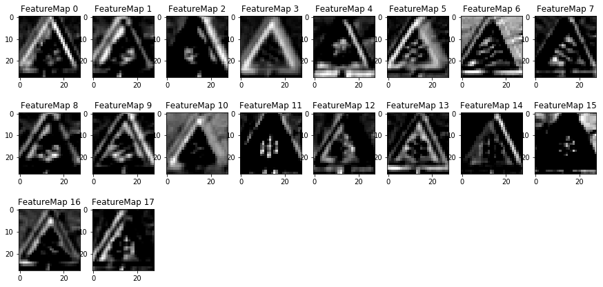

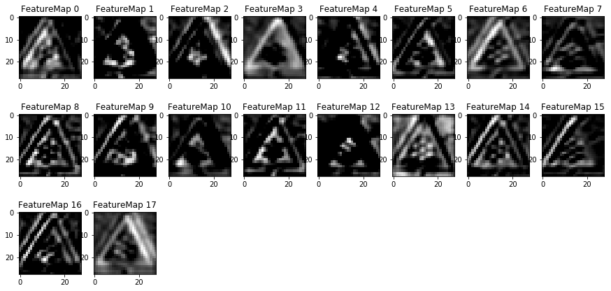

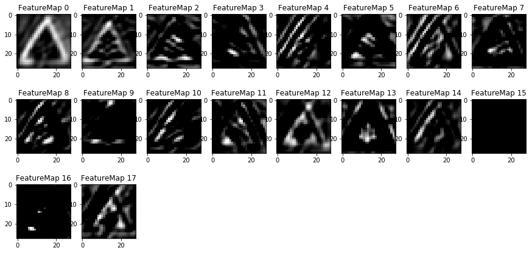

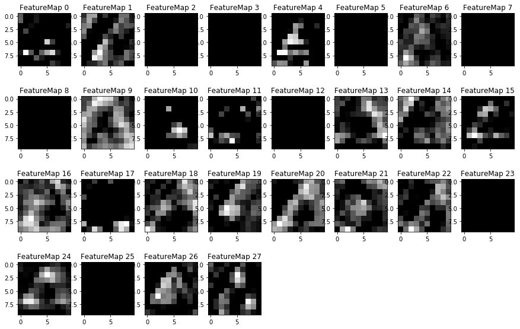

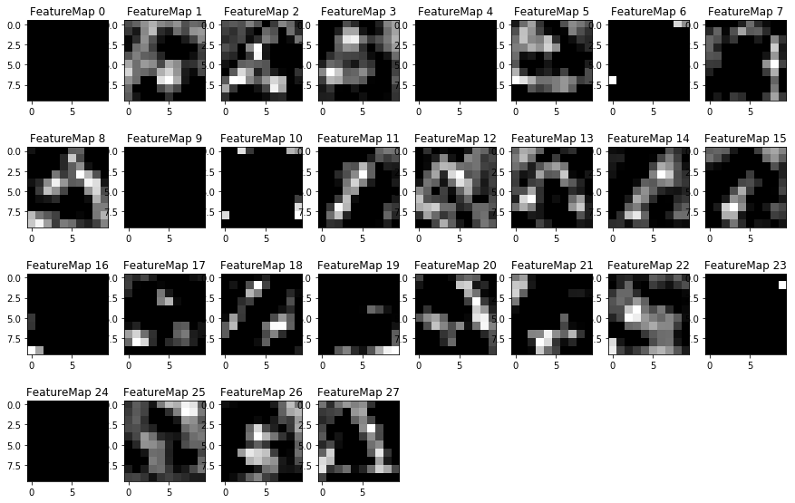

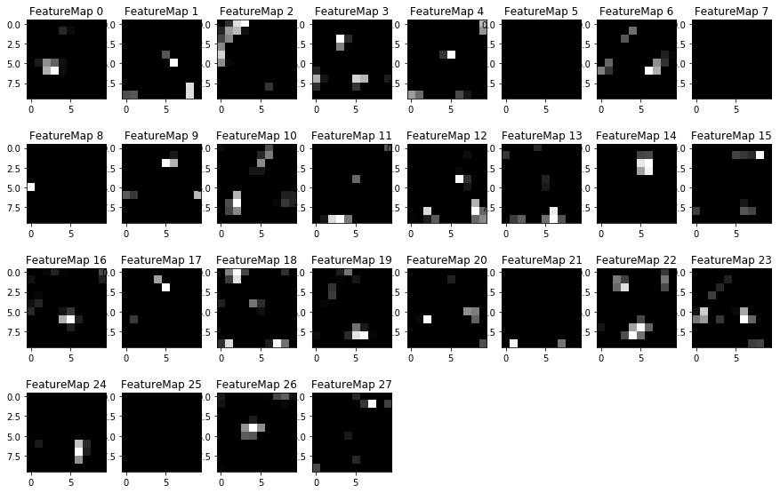

```python
with tf.Session() as sess:
    print(X_new_test_norm.shape)
    sess.run(tf.global_variables_initializer())
    saver4.restore(sess, './CNN_german_traffic_sign-final-17')

    #feed_input = {x_i:[np.array(X_test_norm[0])]}
    #logits_out = sess.run(pred_tensor[0], feed_input)
    #print(pred_tensor[0])

    plt.figure(1)
    plt.imshow(ori_img[0])

    al1_tensor = tf.get_default_graph().get_tensor_by_name("AL1:0")
    outputFeatureMap([np.array(X_new_test_norm[0])], al1_tensor, plt_num=1+1)

    al2_tensor = tf.get_default_graph().get_tensor_by_name("temp_activation:0")
    #print(test)
    outputFeatureMap([np.array(X_new_test_norm[0])], al2_tensor,plt_num=2+1)

    al3_tensor = tf.get_default_graph().get_tensor_by_name("temp0_activation:0")
    outputFeatureMap([np.array(X_new_test_norm[0])], al3_tensor,plt_num=3+1)

    al4_tensor = tf.get_default_graph().get_tensor_by_name("AL2:0")
    outputFeatureMap([np.array(X_new_test_norm[0])], al4_tensor,plt_num=4+1)

    al5_tensor = tf.get_default_graph().get_tensor_by_name("temp1_activation:0")
    outputFeatureMap([np.array(X_new_test_norm[0])], al5_tensor,plt_num=5+1)

    al6_tensor = tf.get_default_graph().get_tensor_by_name("temp10_activation:0")
    outputFeatureMap([np.array(X_new_test_norm[0])], al6_tensor,plt_num=6+1)
```

### Question 9

Discuss how you used the visual output of your trained network's feature maps to show that it had learned to look for interesting characteristics in traffic sign images

**Answer:**: The sign image fed to the model had triangle with snow sign. Each feature map represents different chareteristc of the image, like triangle shape, its edges, snow shape and its edges. For each shape/object within image, some feature map isolates between object with its background. FeatureMap10 shows background while FeatureMap11 only snow edges.

### Project Writeup

Once you have completed the code implementation, document your results in a project writeup using this [template](https://github.com/udacity/CarND-Traffic-Sign-Classifier-Project/blob/master/writeup_template.md) as a guide. The writeup can be in a markdown or pdf file.